# Lecture 23 R Demo – Text

Sam Ventura

November 21, 2016

# Introduction to Text Data

The graphs below don’t have proper titles, axis labels, legends, etc. Please take care to do this on your own graphs.

# Terminology

**Corpus** = a collection of written texts, typically stored electronically in some structured way for processing.

- Plural: corpora
- Etymology: Latin “Corpor” = “body”; i.e. “body of texts”

**Documents** are individual texts in the corpus/collection.

**How do we summarize corpora?** One common approach is using “document-term matrices”:

- Each row is an individual document in the corpus
- Each column represents a unique word that occurs across all documents in the corpus
- Cells can be filled in in several different ways, e.g.:
- `X[i,j] = 1` if word $j$ occurs in document $i$, 0 otherwise
- `X[i,j] =` the “term frequency” of word $j$ in document $i$ (how many times does the word occur in the document?)
- `X[i,j] =` the TF-IDF score of word $j$ in document $i$

Note: Some folks transpose the document-term matrix into a term-document matrix, where the rows are terms, and the columns are documents.

**TF-IDF = “term frequency / inverse document frequency”**:

- Used to determine how “important” a word is to a document in a corpus.
- Increases proportionally to the number of times a word appears in the document (the numerator)
- Decreases proportionally to the number of times the word appears in the entire corpus (the denominator)
- Adjusts for words that are generally more frequent

**Stop words**: Extremely common words that are filtered out before text analysis (e.g. of, the, a, in, at, that, it, etc)

**Stemming**: Reducing a word to a word stem, in order to capture the same word in different forms. E.g.:

- Reducing = reduc
- Reduce = reduc
- Reduced = reduc
- Reducible = reduc
- Reduction = reduc

**Sentiment**: A view of or attitude toward a situation or event; an opinion.

- “I love 315” = good sentiment
- “Professor Ventura is the worst” = bad sentiment

**Sentiment Analysis**: The process of computationally identifying and categorizing opinions expressed in a piece of text, especially in order to determine whether the writer’s attitude towards a particular topic, product, etc., is positive, negative, or neutral.

# Plotting Text

## Most common words / phrases

## Projections of the document-term matrix

## Sentiment Analysis

- See the `tidytext` package and `tidytext::get_sentiments()`
- See the [Tidy Text Mining Book](http://tidytextmining.com/) for some examples!

# Example Text Analysis – Reuter’s Mergers and Acquisitions Articles

You’ll need the `tm` package.

```r
library(ggplot2)
library(tm)
data(acq)
#help(acq)

dtm <- DocumentTermMatrix(acq, control = list(weighting = weightTfIdf,
                                              stopwords = TRUE))
class(dtm)
```

```
## [1] "DocumentTermMatrix"    "simple_triplet_matrix"
```

```r
inspect(dtm[1:5,1:15])
```

```
## <<DocumentTermMatrix (documents: 5, terms: 15)>>
## Non-/sparse entries: 2/73
## Sparsity           : 97%
## Maximal term length: 11
## Weighting          : term frequency - inverse document frequency (normalized) (tf-idf)
##
##     Terms
## Docs -laval       .125 .3322 "...that "(american)      "any "bridge"
##   10      0 0.04275649     0        0           0 0.0000000        0
##   12      0 0.00000000     0        0           0 0.0000000        0
##   44      0 0.00000000     0        0           0 0.0000000        0
##   45      0 0.00000000     0        0           0 0.0248628        0
##   68      0 0.00000000     0        0           0 0.0000000        0
##     Terms
## Docs "final" "it "purolator "shearson "that "there "they "they've
##   10       0   0          0         0     0      0     0        0
##   12       0   0          0         0     0      0     0        0
##   44       0   0          0         0     0      0     0        0
##   45       0   0          0         0     0      0     0        0
##   68       0   0          0         0     0      0     0        0
```

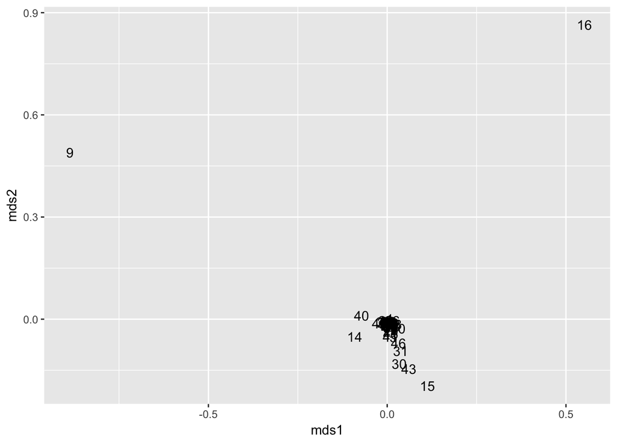

```r
n_mds <- 2
dtm2 <- as.data.frame((as.matrix(dtm)))
dtm_mds <- as.data.frame(cmdscale(dist(dtm2), n_mds))
names(dtm_mds) <- paste0("mds", 1:n_mds)
dtm_mds$index <- 1:nrow(dtm_mds)

ggplot(dtm_mds, aes(mds1, mds2)) + geom_text(aes(label = index))
```

```r
acq[[9]]$content
```

```
## [1] "Liebert Corp said its shareholders\napproved the merger of a wholly-owned subsidiary of Emerson\nElectric Co <EMR>.\n    Under the terms of the merger, each Liebert shareholder\nwill receive .3322 shares of Emerson stock for each Liebert\nshare.\n Reuter"
```

# Example Text Analysis – Reuters Crude Oil Articles

You’ll need the `tm` package.

```r
library(tm)
data(crude)
#help(crude)

dtm <- DocumentTermMatrix(crude, control = list(weighting = weightTfIdf,
                                                stopwords = TRUE))
class(dtm)
```

```
## [1] "DocumentTermMatrix"    "simple_triplet_matrix"
```

```r
inspect(dtm[1:5,1:15])
```

```
## <<DocumentTermMatrix (documents: 5, terms: 15)>>
## Non-/sparse entries: 5/70
## Sparsity           : 93%
## Maximal term length: 10
## Weighting          : term frequency - inverse document frequency (normalized) (tf-idf)
##
##      Terms
## Docs  ... "(it)    "demand "expansion "for "growth "if "is "may "none
##   127   0     0 0.00000000          0    0       0   0   0    0     0
##   144   0     0 0.01588944          0    0       0   0   0    0     0
##   191   0     0 0.00000000          0    0       0   0   0    0     0
##   194   0     0 0.00000000          0    0       0   0   0    0     0
##   211   0     0 0.00000000          0    0       0   0   0    0     0
##      Terms
## Docs       "opec    "opec's "our       "the "there
##   127 0.00000000 0.00000000    0 0.05445784      0
##   144 0.03177888 0.01588944    0 0.02442594      0
##   191 0.00000000 0.00000000    0 0.00000000      0
##   194 0.00000000 0.00000000    0 0.00000000      0
##   211 0.00000000 0.00000000    0 0.00000000      0
```

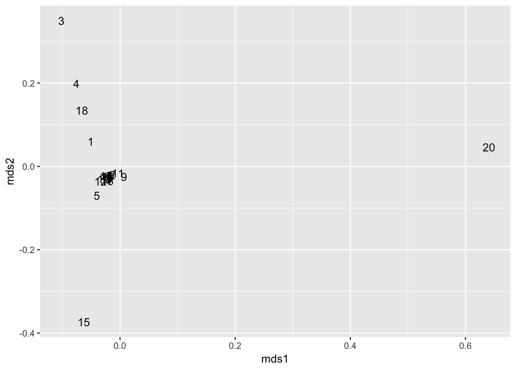

```r
n_mds <- 2
dtm2 <- as.data.frame((as.matrix(dtm)))
dtm_mds <- as.data.frame(cmdscale(dist(dtm2), n_mds))
names(dtm_mds) <- paste0("mds", 1:n_mds)
dtm_mds$index <- 1:nrow(dtm_mds)

ggplot(dtm_mds, aes(mds1, mds2)) + geom_text(aes(label = index))
```

```r
acq[[20]]$content
```

[output not shown]

# Example Text Analysis – Reuters Crude Oil Articles vs. Mergers and Acquisitions Articles

You’ll need the `tm` package.

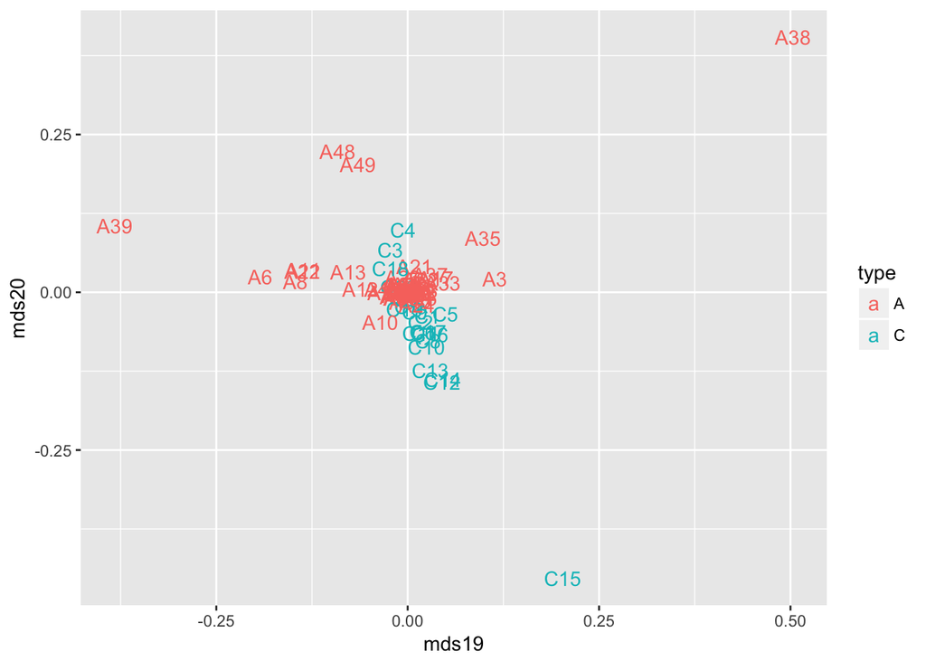

```r
library(tm)
data(crude)
data(acq)
#help(crude)
#help(acq)


dtm_both <- DocumentTermMatrix(c(crude, acq),
                               control = list(weighting = weightTfIdf,
                                              stopwords = TRUE))

n_mds <- 20
dtm2 <- as.data.frame((as.matrix(dtm_both)))
dtm_mds <- as.data.frame(cmdscale(dist(dtm2), n_mds))
names(dtm_mds) <- paste0("mds", 1:n_mds)
dtm_mds$index <- c(paste0("C", 1:20), paste0("A", 1:50))
dtm_mds$type <- c(rep("C", 20), rep("A", 50))

#  Reorder the rows randomly
#  so that the "C" points aren't all covered by the "A" points
dtm_mds <- dtm_mds[sample(1:nrow(dtm_mds), nrow(dtm_mds)),]

ggplot(dtm_mds, aes(mds19, mds20)) + geom_text(aes(label = index, color = type))
```

# Word Clouds

See the [Tidy Text Mining Book](http://tidytextmining.com/).

# Additional Topics

See the [Tidy Text Mining Book](http://tidytextmining.com/).